# Unsupervised Machine Learning Final Project

Aug2023

Data Source: https://www.kaggle.com/datasets/uciml/sms-spam-collection-dataset

# Project Goals

For this project we'll be looking at text messages and classifying them as spam or legitimate (ham) text messages. The data is labeled, and we'll start with using an unsupervised model and compare it against a supervised model. Stepwise, we'll be doing the following:

1. Import the data
2. Clean the data
3. Explore the data
4. Build the unsupervised model
5. Explore improvements to the unsupervised model
6. Build a supervised model
7. Explore improvements to the supervised model
8. Compare supervised vs. unsupervised models
9. Conclusions

# The Data

This data contains text messages collected from a various number of sources (also described in more detail on the Kaggle source url):

1. 425 spam messages from Grumbletext website
2. 3,375 ham messages from NUS SMS Corpus
3. 450 ham messages from Caroline Tag's PhD thesis
4. 1000 ham messages and 322 spam messages from SMS Spam Corpus v.0.1 Big

In total there are 5572 messages with a breakdown of 87% ham and 13% spam.

## NOTE

The data doesn't use the default utf-8 encoding, we need to use ISO-8859-1 to read the raw data correctly.

```python
# Import modules
import polars as pl
import altair as alt
import numpy as np

from sklearn.feature_extraction.text import TfidfVectorizer
from sklearn.decomposition import NMF
from sklearn.model_selection import train_test_split
from sklearn.metrics import confusion_matrix, ConfusionMatrixDisplay

from nltk.tokenize import word_tokenize
from nltk.corpus import stopwords
import enchant

from sklearn.cluster import AgglomerativeClustering as Agg
from sklearn.neighbors import KNeighborsClassifier as KNN
from sklearn.tree import DecisionTreeClassifier as Tree
```

# Import the data

```python
# Import the data
url = "https://raw.githubusercontent.com/nsxydis/final-project/main/spam.csv"
df = pl.read_csv(url, encoding = 'ISO-8859-1')
```

```python
# Clean the data
df.to_pandas().info()

# Review '' column
print("\n'' column")
print(df[''].unique(), '\n')

print('_duplicated_0 column')
print(df['_duplicated_0'].unique())
```

```
<class 'pandas.core.frame.DataFrame'>
RangeIndex: 5572 entries, 0 to 5571
Data columns (total 4 columns):
 #   Column         Non-Null Count  Dtype
---  ------         --------------  -----
 0   v1             5572 non-null   object
 1   v2             5572 non-null   object
 2                  50 non-null     object
 3   _duplicated_0  12 non-null     object
dtypes: object(4)
memory usage: 174.3+ KB

'' column
shape: (44,)
Series: '' [str]
[
	" I don't mind"
	" but dont try …
	" ENJOYIN INDIA…
	" Dont Come Nea…
	" that's the ti…
	" but watever u…
	"GN"
	"just been in b…
	" PO Box 1146 M…
	" PO Box 5249"
	" always give r…
	" justthought i…
	…
	" don't miss ur…
	" GOD said"
	" HOPE UR OK...…
	" but dont try …
	" the person is…
	null
	" the toughest …
	" hopeSo hunny.…
	"this wont even…
	"u hav2hear it!…
	" But at d end …
	"DEVIOUSBITCH.A…
	" smoke hella w…
]

_duplicated_0 column
shape: (11,)
Series: '_duplicated_0' [str]
[
	"U NO THECD ISV…
	" ILLSPEAK 2 U2…
	null
	" TX 4 FONIN HO…
	"IåÕL CALL U\""…
	" MK17 92H. 450…
	" why to miss t…
	"whoever is the…
	"GE"
	" \"OH No! COMP…
	"i wil tolerat.…
]
```

# Data Cleaning

It appears some of the data was split into separate columns because there were commas in the text fields. We'll combine these columns together and clean up the data. Additionally we'll rename the columns and drop unnecessary fields.

```python
def append(x):
    a = x['v2']

    # Get the blank column and add a comma if theres data
    b = x['']
    b = f", {b}" if b != '' else ""

    c = x['_duplicated_0']
    c = f", {c}" if c != '' else ""

    return a + b + c

struct = ['v2', '', '_duplicated_0']
df = df.with_columns(pl.struct(struct).apply(lambda x: append(x)).alias('text'))
df = df.rename({'v1' : 'category'})
df = df.drop(['v2', '', '_duplicated_0'])
```

# Exploring the data

```python
# Add the word count to the data
def wordCount(text):
    return len(text.split(' '))

df = df.with_columns(pl.col('text').apply(lambda x: wordCount(x)).alias('words'))
```

```python
# Explore the data
alt.data_transformers.disable_max_rows()

# Spam vs Ham
title = ['Click the columns to separate the distributions', "Count of spam vs. ham messages"]
selection = alt.selection_point(encodings = ['x'])
breakdown = alt.Chart(df.to_pandas(), title = title).mark_bar().encode(
    x = 'category',
    y = 'count()',
    color = 'category'
).add_params(selection)

# Distribution of message length
title = "Distribution of word counts"
distribution = alt.Chart(df.to_pandas(), title = title).mark_bar().encode(
    x = alt.X('words', bin = True),
    y = 'count()',
    color = 'category'
).transform_filter(selection)

breakdown | distribution
```

[interactive chart not shown]

# Distribution notes

We can see that the normal (ham) messages are mostly under 20 words and skewed whereas the spam messages are typically between 20 to 35 words with a more normal (but still skewed) distribution.

# Model Fitting

Next we'll try fitting a NMF model based on the text field. To do that we'll have to vectorize the words and then fit our model.

```python
# Make a class that can be used for different models
class spamhamNMF:
    def __init__(self, data, testSize = 0.3):
        # Vectorization
        self.vectorizer = TfidfVectorizer()
        self.embed = self.vectorizer.fit(df['text'].to_list())

        # Separate the data
        self.x = data['text'].to_list()
        self.y = data['category'].to_list()

        # Train test split
        self.x_train, self.x_test, self.y_train, self.y_test = \
        train_test_split(self.x, self.y, test_size = testSize, random_state=42)

        # Initialize the model
        self.model = NMF(n_components=2, random_state=42)

    def train(self, report = True):
        '''Predict and score the training data'''
        self.embedTrain = self.vectorizer.transform(self.x_train)
        self.model.fit(self.embedTrain)
        matrix = self.model.transform(self.embedTrain)
        self.ypTrain = [np.argmax(row) for row in matrix]

        # Score
        self.trainScore, self.ypTrain = self.score(self.y_train, self.ypTrain, train = True)
        if report:
            print(f"Train Accuracy: {round(self.trainScore * 100, 2)}%")


    def test(self, report = True):
        '''Predict and score the test data'''
        self.embedTest = self.vectorizer.transform(self.x_test)
        matrix = self.model.transform(self.embedTest)
        self.ypTest = [np.argmax(row) for row in matrix]

        # Score
        self.testScore, self.ypTest = self.score(self.y_test, self.ypTest, train = False)
        if report:
            print(f"Test Accuracy: {round(self.testScore * 100, 2)}%")

    def score(self, y, yp, train = True):
        '''Categories yp and scores it against y'''
        if train:
            # Determine which number aligns with each group
            df = pl.DataFrame({'y' : y, 'yp' : yp})
            ham = df.filter(pl.col('y') == 'ham')
            spam = df.filter(pl.col('y') == 'spam')

            ypHam = ham['yp'].mode()[0]
            ypSpam = spam['yp'].mode()[0]

            # Check that both groups weren't assigned together
            if ypHam == ypSpam:
                alternate = 1 if ypHam == 0 else 1

                if len(ham) > len(spam):
                    ypSpam = alternate
                else:
                    ypHam = alternate

            # Create a dictionary
            if ypHam == 0:
                pred = {0 : 'ham', 1 : 'spam'}
            else:
                pred = {0 : 'spam', 1 : 'ham'}
            self.pred = pred
        else:
            pred = self.pred

        # Convert the predictions
        ypConverted = []
        for item in yp:
            ypConverted.append(pred[item])

        # Score the accuracy
        count = 0
        for n in range(len(y)):
            if y[n] == ypConverted[n]:
                count += 1

        # Return the accuracy and converted yp
        return count / len(y), ypConverted
```

```python
# Plot and describe the model results
def results(y, yp):
    '''NOTE: ham == 0 and spam == 1'''
    y = np.array(y)
    yp = np.array(yp)
    dfTemp = pl.DataFrame({'y' : y, 'yp' : yp})

    total = len(y)
    correct = sum(yp == y)

    # False negative and true positive rate
    positive = dfTemp.filter(pl.col('y') == 'spam')
    falseNegative = len(positive.filter(pl.col('yp') == 'ham'))
    truePositive = len(positive.filter(pl.col('yp') == 'spam'))

    # False positive and true negative rate
    negative = dfTemp.filter(pl.col('y') == 'ham')
    falsePositive = len(negative.filter(pl.col('yp') == 'spam'))
    trueNegative = len(negative.filter(pl.col('yp') == 'ham'))

    # Number of spam messages correctly identified
    spamrate = round(truePositive / len(positive) * 100, 2)
    print(f"{spamrate}% of spam messages were correctly classified")

    # Number of real messages misclassified
    realrate = round(trueNegative / len(negative) * 100, 2)
    print(f"{realrate}% of normal messages were correctly classified.")

    # Plot the confusion matrix
    _ = ConfusionMatrixDisplay(confusion_matrix(y, yp)).plot()
```

```
Train Accuracy: 51.69%
Test Accuracy: 53.95%
13.7% of spam messages were correctly classified
60.01% of normal messages were correctly classified.
```

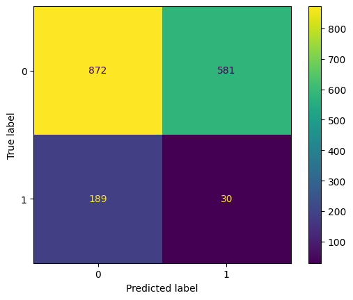

```python
nmf = spamhamNMF(df)
nmf.train()
nmf.test()
results(nmf.y_test, nmf.ypTest)
```

# NMF Model improvements Part 1

Let's try removing stop words and seeing the impact.

```python
def stopWords(text):
    '''Remove stopwords from the text'''
    stop = set(stopwords.words('english'))
    words = word_tokenize(text)
    new = ""
    for word in words:
        if word not in stop and (word.replace('-', "").isalnum()):
            new += f" {word}"
    return new

dfImproved = df.with_columns(pl.col('text').apply(lambda x: stopWords(x)))
```

```
Train Accuracy: 86.36%
Test Accuracy: 86.48%
48.86% of spam messages were correctly classified
92.15% of normal messages were correctly classified.
```

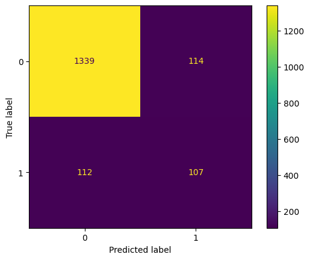

```python
nmf = spamhamNMF(dfImproved)
nmf.train()
nmf.test()
results(nmf.y_test, nmf.ypTest)
```

# NMF Model Improvements Part 1 Results

Removing stopwords from the data greatly improved the NMF model, taking accuracy from 51.7% to 86.5%. We should note that while the correct classification rate for normal messages is 92.2%, the correct rate for spam is only 48.9%, which is not the best.

# NMF Model improvements Part 2

Let's try converting slang words and abbreviations to plain english.

```python
dfSlang = {}
d = enchant.Dict('en_US')
def slang(text):
    '''Creates a list of slang words if there are any, otherwise returns []'''
    slangWords = []
    words = word_tokenize(text)
    for word in words:
        if d.check(word) == False:
            slangWords.append(word)
            if word.lower() not in dfSlang:
                dfSlang[word.lower()] = 1
            else:
                dfSlang[word.lower()] += 1
    return slangWords

dfImproved2 = dfImproved.with_columns(pl.col('text').apply(lambda x: slang(x)).alias('slang'))
```

```python
# Identify the most used slang words
temp = {
    'word' : [],
    'count' : []
}
for word in dfSlang:
    temp['word'].append(word)
    temp['count'].append(dfSlang[word])

dfSlang = pl.DataFrame(temp)
del temp
dfSlang = dfSlang.sort(by = 'count', descending = True)
dfSlang = dfSlang.filter(pl.col('count') > 20)
```

```python
# Manually adjusted slang translation
slangTranslation = {'lt': 'love that',
 'ur': 'your',
 'ok': 'okay',
 'txt': 'text',
 'lor': '?',
 'da': 'dad',
 'dont': "do not",
 'pls': 'please',
 'na': 'no',
 'im': 'I am',
 'msg': 'message',
 'lol': 'laughing out loud',
 'gon': 'gone',
 'gud': 'good',
 'ìï': '?',
 'haha': 'hah',
 'thk': 'thanks',
 'mins': 'minutes',
 'sms': 'message',
 'thats': 'that is',
 'liao': 'already',
 'luv': 'love',
 '150ppm': '150 parts per million',
 'aight': 'alright',
 'thanx': 'thanks',
 'leh': 'you',
 'didnt': 'did not',
 'tmr': 'tomorrow',
 'wif': 'wife',
 '150p': '150 parts per million',
 'hav': 'have',
 'abt': 'about',
 'juz': 'just',
 'tv': 'television',
 'plz': 'please',
 'havent': 'have not',
 'haf': 'have',
 'oso': 'significant other',
 'goin': 'going',
 'colour': 'color',
 'todays': "today's",
 'wid': 'with',
 'sae': '?'}
```

```python
# Function to add slang words to our translator
def translate(slangWord):
    if word not in slangTranslation:
        slangTranslation[word] = input(f"{word}: ")

for word in dfSlang['word'].to_list():
    translate(word)
```

```python
# Convert the slang words to normal words
def convertSlang(text):
    words = word_tokenize(text)
    new = ""
    for word in words:
        if word.lower() in slangTranslation:
            word = slangTranslation[word.lower()]
            if word == "?":
                word = ""
        new += f" {word}"
    return new

dfImproved2 = dfImproved2.with_columns(pl.col('text').apply(lambda x: convertSlang(x)))
```

```
Train Accuracy: 81.72%
Test Accuracy: 82.36%
0.0% of spam messages were correctly classified
94.77% of normal messages were correctly classified.
```

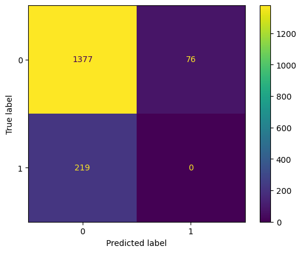

```python
nmf = spamhamNMF(dfImproved2)
nmf.train()
nmf.test()
results(nmf.y_test, nmf.ypTest)
```

# NMF Model Improvements Part 2 Results

From our second round of changes we see that the performance has declined from 86.5% to 82.4%. More worringly, we no longer idenify any of the spam messages. This suggests that the use of slang is important in separating spam from actual text messages. The second round of updates will not be incorporated in future runs.

# Agglomerative Clustering

Next we'll try out a different unsupervised model to see if we can improve performance over the NMF model. We'll use agglomerative clustering.

```python
class spamhamAgg:
    def __init__(self, data, testSize = 0.3):
        # Vectorization
        self.vectorizer = TfidfVectorizer()
        self.embed = self.vectorizer.fit(df['text'].to_list())

        # Separate the data
        self.x = data['text'].to_list()
        self.y = data['category'].to_list()

        # Train test split
        self.x_train, self.x_test, self.y_train, self.y_test = \
        train_test_split(self.x, self.y, test_size = testSize, random_state=42)

        # Initialize the model
        self.model = Agg(n_clusters=2)

    def train(self, report = True):
        '''Predict and score the training data'''
        self.embedTrain = self.vectorizer.transform(self.x_train)
        self.ypTrain = self.model.fit_predict(self.embedTrain.toarray())

        # Score
        self.trainScore, self.ypTrain = self.score(self.y_train, self.ypTrain, train = True)
        if report:
            print(f"Train Accuracy: {round(self.trainScore * 100, 2)}%")

    def test(self, report = True):
        '''Predict and score the test data'''
        self.embedTest = self.vectorizer.transform(self.x_test)
        self.ypTest = self.model.fit_predict(self.embedTest.toarray())

        # Score
        self.testScore, self.ypTest = self.score(self.y_test, self.ypTest, train = False)
        if report:
            print(f"Test Accuracy: {round(self.testScore * 100, 2)}%")

    def score(self, y, yp, train = True):
        '''Categories yp and scores it against y'''
        if train:
            # Determine which cluster aligns with each group
            df = pl.DataFrame({'y' : y, 'yp' : yp})
            ham = df.filter(pl.col('y') == 'ham')
            spam = df.filter(pl.col('y') == 'spam')

            ypHam = ham['yp'].mode()[0]
            ypSpam = spam['yp'].mode()[0]

            # Check that both groups weren't assigned together
            if ypHam == ypSpam:
                alternate = 1 if ypHam == 0 else 1

                if len(ham) > len(spam):
                    ypSpam = alternate
                else:
                    ypHam = alternate

            # Create a dictionary
            if ypHam == 0:
                pred = {0 : 'ham', 1 : 'spam'}
            else:
                pred = {0 : 'spam', 1 : 'ham'}
            self.pred = pred
        else:
            pred = self.pred

        # Convert the predictions
        ypConverted = []
        for item in yp:
            ypConverted.append(pred[item])

        # Score the accuracy
        count = 0
        for n in range(len(y)):
            if y[n] == ypConverted[n]:
                count += 1

        # Return the accuracy and converted yp
        return count / len(y), ypConverted
```

```
Train Accuracy: 85.95%
Test Accuracy: 85.89%
0.0% of spam messages were correctly classified
98.83% of normal messages were correctly classified.
```

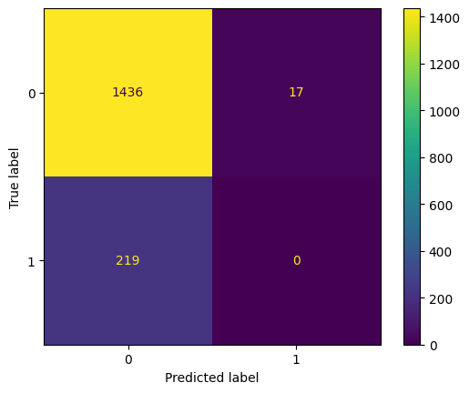

```python
agg = spamhamAgg(df)
agg.train()
agg.test()
results(agg.y_test, agg.ypTest)
```

```
Train Accuracy: 85.92%
Test Accuracy: 85.94%
0.0% of spam messages were correctly classified
98.9% of normal messages were correctly classified.
```

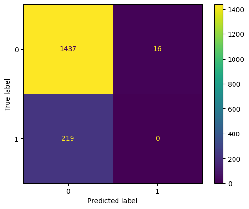

```python
agg = spamhamAgg(dfImproved)
agg.train()
agg.test()
results(agg.y_test, agg.ypTest)
```

```
Train Accuracy: 84.46%
Test Accuracy: 84.39%
0.0% of spam messages were correctly classified
97.11% of normal messages were correctly classified.
```

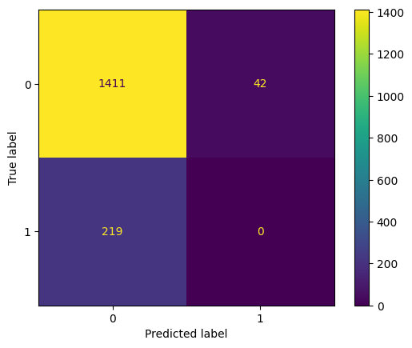

```python
agg = spamhamAgg(dfImproved2)
agg.train()
agg.test()
results(agg.y_test, agg.ypTest)
```

# Agglomerative Clustering Results

Running the second unsupervised method against the standard and improved (stopwords removed) data did not yield very good results. The accuracy is similar to the NMF model, but it doesn't correctly identify spam messages. Since the performance is so poor, we won't evaluate this model further.

# KNN Model

Next we'll take a look at a couple of supervised classification models, starting with k-nearest-neighbors. We'll identify the optimal number of neighbors first and then run the model against the original and improved data.

```python
class spamhamKNN:
    def __init__(self, data, neighbors = 3, testSize = 0.3):
        # Vectorization
        self.vectorizer = TfidfVectorizer()
        self.embed = self.vectorizer.fit(df['text'].to_list())

        # Separate the data
        self.x = data['text'].to_list()
        self.y = data['category'].to_list()

        # Train test split
        self.x_train, self.x_test, self.y_train, self.y_test = \
        train_test_split(self.x, self.y, test_size = testSize, random_state=42)

        # Initialize the model
        self.model = KNN(n_neighbors=neighbors)

    def train(self, report = True):
        '''Predict and score the training data'''
        self.embedTrain = self.vectorizer.transform(self.x_train)
        self.model.fit(self.embedTrain, self.y_train)
        self.ypTrain = self.model.predict(self.embedTrain)
        self.trainAccuracy = self.model.score(self.embedTrain, self.y_train)
        if report:
            print(f"Train Accuracy: {round(self.trainAccuracy * 100, 2)}%")

    def test(self, report = True):
        '''Predict and score the test data'''
        self.embedTest = self.vectorizer.transform(self.x_test)
        self.ypTest = self.model.predict(self.embedTest)
        self.testAccuracy = self.model.score(self.embedTest, self.y_test)
        if report:
            print(f"Test Accuracy: {round(self.testAccuracy * 100, 2)}%")
```

```python
for n in range(1, 11, 2):
    print(f"{n} neighbors")
    knn = spamhamKNN(df, neighbors=n)
    knn.train()
    knn.test()
```

```
1 neighbors
Train Accuracy: 100.0%
Test Accuracy: 98.21%
3 neighbors
Train Accuracy: 98.36%
Test Accuracy: 97.25%
5 neighbors
Train Accuracy: 97.64%
Test Accuracy: 96.89%
7 neighbors
Train Accuracy: 97.51%
Test Accuracy: 96.89%
9 neighbors
Train Accuracy: 97.44%
Test Accuracy: 97.01%
```

# KNN number of neighbors

We get good results with 1 to 3 neighbors. Since neighbors == 1 can be more sensitive to noise and overfitting, we'll use 3 neighbors instead.

```
Train Accuracy: 98.36%
Test Accuracy: 97.25%
79.45% of spam messages were correctly classified
99.93% of normal messages were correctly classified.
```

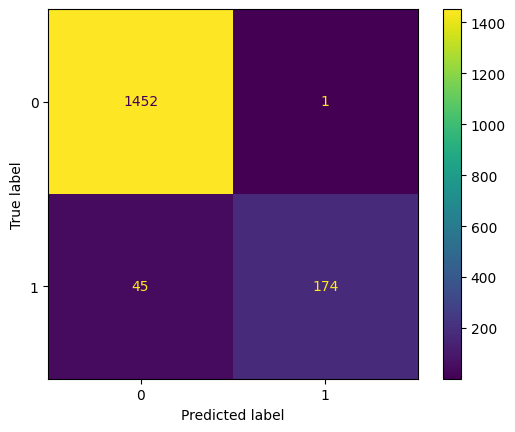

```python
# The Best KNN model
knn = spamhamKNN(df, neighbors = 3)
knn.train()
knn.test()
results(knn.y_test, knn.ypTest)
```

```
Train Accuracy: 97.79%
Test Accuracy: 96.41%
73.52% of spam messages were correctly classified
99.86% of normal messages were correctly classified.
```

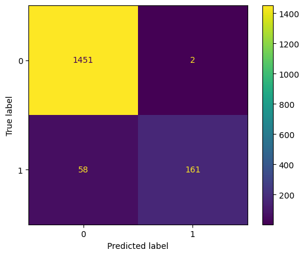

```python
# Test against the improved data
knn = spamhamKNN(dfImproved, neighbors = 3)
knn.train()
knn.test()
results(knn.y_test, knn.ypTest)
```

```
Train Accuracy: 97.92%
Test Accuracy: 96.71%
75.34% of spam messages were correctly classified
99.93% of normal messages were correctly classified.
```

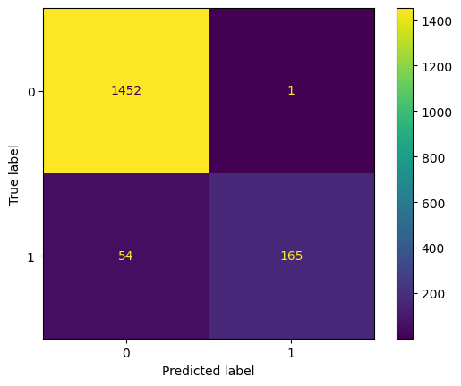

```python
# Test against the second improved data
knn = spamhamKNN(dfImproved2, neighbors = 3)
knn.train()
knn.test()
results(knn.y_test, knn.ypTest)
```

```python
class spamhamTree:
    def __init__(self, data, max_depth = None, testSize = 0.3):
        # Vectorization
        self.vectorizer = TfidfVectorizer()
        self.embed = self.vectorizer.fit(df['text'].to_list())

        # Separate the data
        self.x = data['text'].to_list()
        self.y = data['category'].to_list()

        # Train test split
        self.x_train, self.x_test, self.y_train, self.y_test = \
        train_test_split(self.x, self.y, test_size = testSize, random_state=42)

        # Initialize the model
        self.model = Tree(random_state=42, max_depth=max_depth)

    def train(self, report = True):
        '''Predict and score the training data'''
        self.embedTrain = self.vectorizer.transform(self.x_train)
        self.model.fit(self.embedTrain, self.y_train)
        self.ypTrain = self.model.predict(self.embedTrain)
        self.trainAccuracy = self.model.score(self.embedTrain, self.y_train)
        if report:
            print(f"Train Accuracy: {round(self.trainAccuracy * 100, 2)}%")

    def test(self, report = True):
        '''Predict and score the test data'''
        self.embedTest = self.vectorizer.transform(self.x_test)
        self.ypTest = self.model.predict(self.embedTest)
        self.testAccuracy = self.model.score(self.embedTest, self.y_test)
        if report:
            print(f"Test Accuracy: {round(self.testAccuracy * 100, 2)}%")
```

```python
depths = [n for n in range(0, 20, 2)]
for depth in depths:
    if depth == 0:
        depth = None
    print(f"Depth: {depth}")
    tree = spamhamTree(df, max_depth=depth)
    tree.train()
    tree.test()
```

```
Depth: None
Train Accuracy: 100.0%
Test Accuracy: 96.41%
Depth: 2
Train Accuracy: 91.18%
Test Accuracy: 92.22%
Depth: 4
Train Accuracy: 95.31%
Test Accuracy: 95.16%
Depth: 6
Train Accuracy: 96.74%
Test Accuracy: 96.35%
Depth: 8
Train Accuracy: 97.74%
Test Accuracy: 96.89%
Depth: 10
Train Accuracy: 98.21%
Test Accuracy: 96.95%
Depth: 12
Train Accuracy: 98.54%
Test Accuracy: 96.95%
Depth: 14
Train Accuracy: 98.9%
Test Accuracy: 96.89%
Depth: 16
Train Accuracy: 99.13%
Test Accuracy: 96.89%
Depth: 18
Train Accuracy: 99.28%
Test Accuracy: 96.89%
```

```
Train Accuracy: 98.21%
Test Accuracy: 96.95%
81.28% of spam messages were correctly classified
99.31% of normal messages were correctly classified.
```

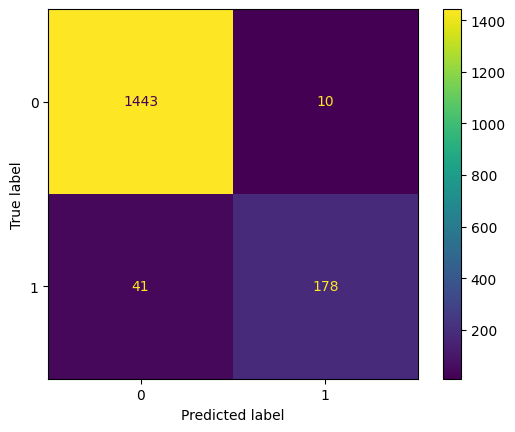

```python
# Best decision tree model
tree = spamhamTree(df, max_depth=10)
tree.train()
tree.test()
results(tree.y_test, tree.ypTest)
```

```
Train Accuracy: 98.41%
Test Accuracy: 96.35%
80.82% of spam messages were correctly classified
98.69% of normal messages were correctly classified.
```

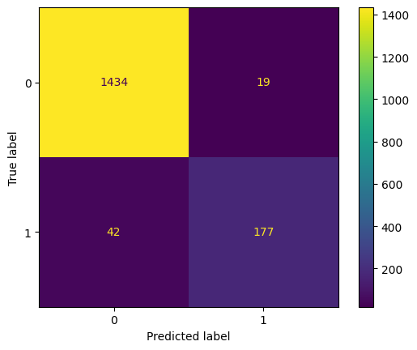

```python
# Best decision tree model: Improved data
tree = spamhamTree(dfImproved, max_depth=10)
tree.train()
tree.test()
results(tree.y_test, tree.ypTest)
```

```
Train Accuracy: 98.41%
Test Accuracy: 96.11%
79.0% of spam messages were correctly classified
98.69% of normal messages were correctly classified.
```

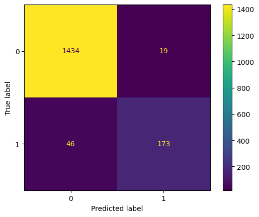

```python
# Best decision tree model: Improved data 2
tree = spamhamTree(dfImproved2, max_depth=10)
tree.train()
tree.test()
results(tree.y_test, tree.ypTest)
```

# Conclusion

While evaluating this issue we used unsupervised and supervised models to try and sort spam versus ham text messages. The NMF model performed best of the unsupervised models. Unfortunately the Agglomerative approach did not classify many of the messages as spam (in fact it missed all of the spam messages). For the supervised models, KNN & the Decision Tree both performed comparably well, though the KNN model had higher accuracy and lower false positives. False positives in this instance would mean a normal text message would be flagged as spam and potentially blocked -- this is the worst possible outcome because it would prevent communication. Because of that, the KNN model is best.

Overall, the supervised model performed better than the unsupervised models. So, in this instance, we'd recommend using the k-nearest neighbors approach when trying to sort text messages. Additionally, the model performs best when using the untransformed data, so there are fewer data transformations needed, which can be beneficial to processing time. These are the final results:

- Train Accuracy: 98.36%
- Test Accuracy: 97.25%
- 79.45% of spam messages were correctly classified
- 99.93% of normal messages were correctly classified.